# R Notebook

# Practica Libro PDF. Ver punto 3.6.

```r
rm(list=ls())
```

```r
library(MASS) #contiene un conjunto de datasets de la leche.
#install.packages("ISLR")
library(ISLR)
```

We will seek to predict medv using 13 predictors such as rm (average number of rooms per house), age (average age of houses), and lstat (percent of households with low socioeconomic status).

```r
data("Boston")
attach(Boston)
head(Boston)
```

|  | crim | zn | indus | chas | nox | rm | age | dis | rad | tax | ptratio | black | lstat | medv |
| --- | --- | --- | --- | --- | --- | --- | --- | --- | --- | --- | --- | --- | --- | --- |
| 1 | 0.00632 | 18 | 2.31 | 0 | 0.538 | 6.575 | 65.2 | 4.0900 | 1 | 296 | 15.3 | 396.90 | 4.98 | 24.0 |
| 2 | 0.02731 | 0 | 7.07 | 0 | 0.469 | 6.421 | 78.9 | 4.9671 | 2 | 242 | 17.8 | 396.90 | 9.14 | 21.6 |
| 3 | 0.02729 | 0 | 7.07 | 0 | 0.469 | 7.185 | 61.1 | 4.9671 | 2 | 242 | 17.8 | 392.83 | 4.03 | 34.7 |
| 4 | 0.03237 | 0 | 2.18 | 0 | 0.458 | 6.998 | 45.8 | 6.0622 | 3 | 222 | 18.7 | 394.63 | 2.94 | 33.4 |
| 5 | 0.06905 | 0 | 2.18 | 0 | 0.458 | 7.147 | 54.2 | 6.0622 | 3 | 222 | 18.7 | 396.90 | 5.33 | 36.2 |
| 6 | 0.02985 | 0 | 2.18 | 0 | 0.458 | 6.430 | 58.7 | 6.0622 | 3 | 222 | 18.7 | 394.12 | 5.21 | 28.7 |

```r
names(Boston)
```

```
 [1] "crim"    "zn"      "indus"   "chas"    "nox"     "rm"      "age"     "dis"     "rad"     "tax"     "ptratio" "black"
[13] "lstat"   "medv"
```

Vamos a realizar inicialmente una regresión linal simple.

```r
mod <- lm(medv~lstat)
summary(mod)
```

```
Call:
lm(formula = medv ~ lstat)

Residuals:
    Min      1Q  Median      3Q     Max
-15.168  -3.990  -1.318   2.034  24.500

Coefficients:
            Estimate Std. Error t value Pr(>|t|)
(Intercept) 34.55384    0.56263   61.41   <2e-16 ***
lstat       -0.95005    0.03873  -24.53   <2e-16 ***
---
Signif. codes:  0 ‘***’ 0.001 ‘**’ 0.01 ‘*’ 0.05 ‘.’ 0.1 ‘ ’ 1

Residual standard error: 6.216 on 504 degrees of freedom
Multiple R-squared:  0.5441,    Adjusted R-squared:  0.5432
F-statistic: 601.6 on 1 and 504 DF,  p-value: < 2.2e-16
```

```r
names(mod)
```

```
 [1] "coefficients"  "residuals"     "effects"       "rank"          "fitted.values" "assign"        "qr"
 [8] "df.residual"   "xlevels"       "call"          "terms"         "model"
```

```r
coef(mod)
```

```
(Intercept)       lstat
 34.5538409  -0.9500494
```

Para obtener los intervalos de confianza para los coeficientes:

```r
confint(mod)
```

```
                2.5 %     97.5 %
(Intercept) 33.448457 35.6592247
lstat       -1.026148 -0.8739505
```

Hacer una predicción sobre el modelo. Por defecto lo hace a un intervalo del 95% pero se puede especificar otro

```r
predict.lm(mod,data.frame(lstat=(c(5,10,15))), interval ="prediction")
```

```
       fit       lwr      upr
1 29.80359 17.565675 42.04151
2 25.05335 12.827626 37.27907
3 20.30310  8.077742 32.52846
```

```r
predict.lm(mod,data.frame(lstat=(c(5,10,15))), interval ="prediction", level=0.90)
```

```
       fit      lwr      upr
1 29.80359 19.53900 40.06818
2 25.05335 14.79899 35.30771
3 20.30310 10.04905 30.55715
```

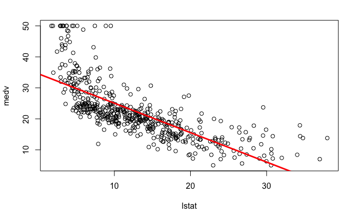

```r
plot(lstat ,medv)
abline(mod,lwd=3, col="red")
```

Existe alguna evidencia de no linealidad en la relación entre lstat y medv. Exploraremos este problema más adelante en este laboratorio.

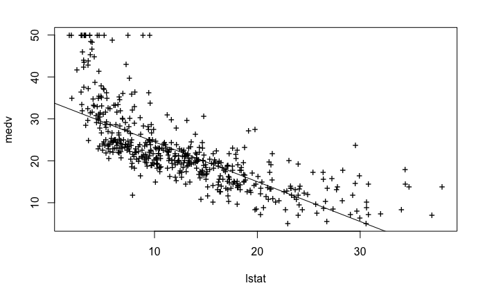

```r
plot(lstat,medv,pch="+")
abline(34,-0.95)
```

Graficos importantes para entender si el modelo se ajusta ok.

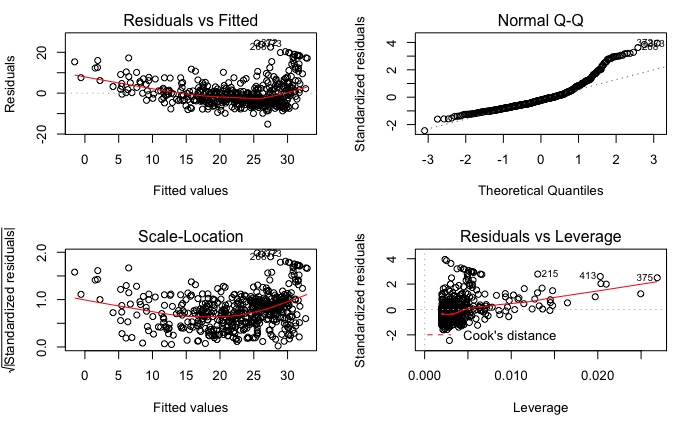

```r
par(mfrow=c(2,2))
plot(mod)
```

Vemos varias cosas interesantes.

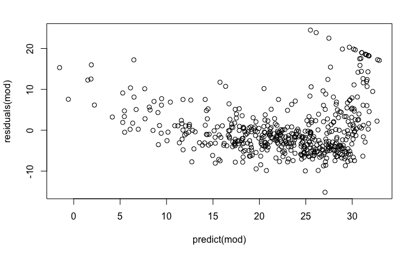

```r
plot(predict(mod), residuals(mod))
```

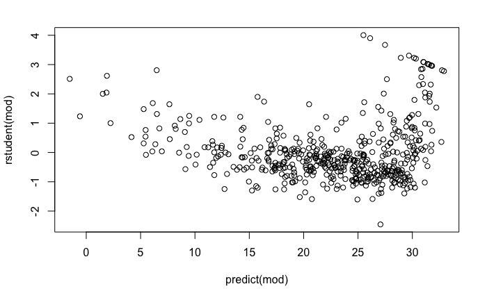

```r
plot(predict(mod), rstudent(mod))
```

Sobre la base de las parcelas residuales, hay alguna evidencia de no linealidad ya que vemos algún patrón en los residuos.

Podemos ver también una estadistica de puntos “Leverage”

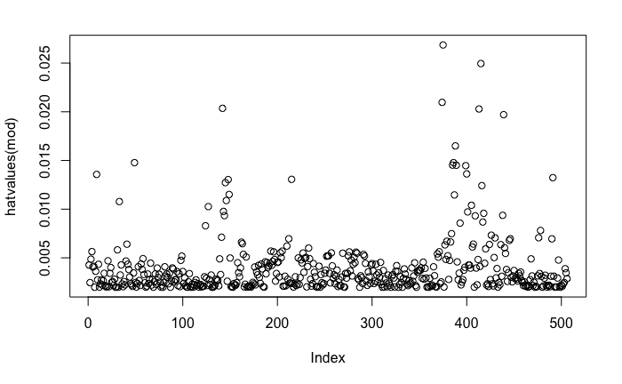

```r
plot(hatvalues (mod))
```

```r
which.max(hatvalues (mod))
```

```
375
375
```

Si hubies algún punto que estuviese fastiadiando la muestra por estar fuera del rango que representamos en X, debería mostrarse el punto indicando su valor X correspondiente. En este caso no detectamos High Leverage Points. Puntos de alta influencia.

VAMOS A TRATAR DE AJUSTARLA UN POCO MEJOR, por ejemplo utilizando una función cuadrática

```r
lstat_quad<-lstat^2
mod_quad <- lm(medv~lstat+lstat_quad)
summary(mod_quad)
```

```
Call:
lm(formula = medv ~ lstat + lstat_quad)

Residuals:
     Min       1Q   Median       3Q      Max
-15.2834  -3.8313  -0.5295   2.3095  25.4148

Coefficients:
             Estimate Std. Error t value Pr(>|t|)
(Intercept) 42.862007   0.872084   49.15   <2e-16 ***
lstat       -2.332821   0.123803  -18.84   <2e-16 ***
lstat_quad   0.043547   0.003745   11.63   <2e-16 ***
---
Signif. codes:  0 ‘***’ 0.001 ‘**’ 0.01 ‘*’ 0.05 ‘.’ 0.1 ‘ ’ 1

Residual standard error: 5.524 on 503 degrees of freedom
Multiple R-squared:  0.6407,    Adjusted R-squared:  0.6393
F-statistic: 448.5 on 2 and 503 DF,  p-value: < 2.2e-16
```

```r
sort(lstat)
```

```
  [1]  1.73  1.92  1.98  2.47  2.87  2.88  2.94  2.96  2.97  2.98  3.01  3.11  3.11  3.13  3.16  3.16  3.26  3.32  3.33  3.53  3.53
 [22]  3.54  3.56  3.57  3.59  3.70  3.73  3.76  3.76  3.81  3.92  3.95  3.95  4.03  4.08  4.14  4.16  4.21  4.32  4.38  4.45  4.45
 [43]  4.50  4.54  4.56  4.56  4.59  4.59  4.61  4.63  4.67  4.69  4.70  4.73  4.74  4.81  4.82  4.84  4.85  4.86  4.97  4.98  5.03
 [64]  5.04  5.08  5.10  5.12  5.19  5.21  5.25  5.28  5.29  5.29  5.33  5.33  5.39  5.49  5.49  5.50  5.50  5.52  5.57  5.64  5.68
 [85]  5.68  5.70  5.77  5.81  5.89  5.90  5.91  5.98  5.98  5.99  6.05  6.07  6.12  6.15  6.19  6.21  6.27  6.29  6.36  6.36  6.36
[106]  6.43  6.47  6.48  6.53  6.56  6.57  6.58  6.58  6.59  6.62  6.65  6.68  6.72  6.72  6.73  6.75  6.78  6.86  6.87  6.90  6.92
[127]  6.93  7.01  7.12  7.14  7.18  7.19  7.20  7.22  7.26  7.34  7.37  7.39  7.39  7.43  7.44  7.44  7.51  7.53  7.54  7.56  7.60
[148]  7.60  7.67  7.70  7.73  7.74  7.79  7.79  7.79  7.83  7.85  7.88  7.90  8.01  8.05  8.05  8.05  8.10  8.10  8.16  8.20  8.23
[169]  8.26  8.43  8.44  8.47  8.51  8.58  8.61  8.65  8.67  8.77  8.79  8.81  8.88  8.93  8.94  9.04  9.08  9.09  9.10  9.14  9.16
[190]  9.22  9.25  9.28  9.29  9.38  9.42  9.43  9.45  9.47  9.50  9.50  9.51  9.52  9.53  9.54  9.55  9.59  9.62  9.64  9.67  9.68
[211]  9.69  9.71  9.74  9.80  9.81  9.88  9.93  9.97  9.97 10.11 10.11 10.13 10.15 10.16 10.19 10.21 10.24 10.26 10.27 10.29 10.30
[232] 10.36 10.40 10.42 10.45 10.45 10.50 10.53 10.56 10.58 10.59 10.63 10.74 10.87 10.88 10.97 11.10 11.12 11.22 11.25 11.28 11.32
[253] 11.34 11.38 11.41 11.45 11.48 11.50 11.64 11.65 11.66 11.69 11.72 11.74 11.97 11.98 12.01 12.03 12.03 12.04 12.12 12.13 12.14
[274] 12.26 12.27 12.33 12.34 12.40 12.43 12.43 12.50 12.60 12.64 12.67 12.67 12.73 12.79 12.80 12.86 12.87 12.92 12.93 13.00 13.00
[295] 13.04 13.09 13.11 13.15 13.15 13.22 13.27 13.27 13.28 13.33 13.34 13.35 13.44 13.44 13.45 13.51 13.59 13.61 13.65 13.83 13.98
[316] 13.99 14.00 14.09 14.10 14.10 14.10 14.13 14.15 14.19 14.27 14.33 14.36 14.37 14.43 14.44 14.52 14.59 14.64 14.65 14.66 14.67
[337] 14.69 14.70 14.76 14.79 14.80 14.81 14.81 14.98 15.02 15.02 15.03 15.10 15.12 15.17 15.17 15.37 15.39 15.55 15.69 15.70 15.71
[358] 15.76 15.79 15.84 15.94 16.03 16.14 16.20 16.21 16.22 16.23 16.29 16.30 16.35 16.42 16.44 16.47 16.51 16.59 16.65 16.74 16.90
[379] 16.94 16.96 17.09 17.10 17.11 17.12 17.15 17.16 17.19 17.21 17.27 17.27 17.28 17.31 17.44 17.58 17.60 17.60 17.64 17.73 17.79
[400] 17.92 17.93 18.03 18.05 18.06 18.06 18.07 18.13 18.13 18.13 18.14 18.33 18.34 18.35 18.46 18.46 18.66 18.68 18.71 18.72 18.76
[421] 18.80 18.85 19.01 19.15 19.31 19.37 19.52 19.69 19.77 19.78 19.88 19.92 20.08 20.31 20.32 20.34 20.45 20.62 20.85 21.02 21.08
[442] 21.14 21.22 21.24 21.32 21.32 21.45 21.46 21.52 21.78 22.11 22.60 22.74 22.88 22.98 23.09 23.24 23.27 23.29 23.34 23.60 23.69
[463] 23.79 23.97 23.98 23.98 24.08 24.10 24.16 24.39 24.56 24.91 25.41 25.68 25.79 26.40 26.42 26.45 26.64 26.77 26.82 27.26 27.38
[484] 27.71 27.80 28.28 28.32 29.05 29.29 29.53 29.55 29.68 29.93 29.97 30.59 30.62 30.63 30.81 30.81 31.99 34.02 34.37 34.41 34.77
[505] 36.98 37.97
```

```r
max(lstat)
```

```
[1] 37.97
```

```r
min(lstat)
```

```
[1] 1.73
```

vamos a generar valores con nuestro nuevo modelo para pintar la gráfica y ver que tal se ajusta.

```r
lstat_values <- seq(1.80, 38.00, 0.10)
```

```r
predictedcounts <- predict(mod_quad,list(lstat=lstat_values, lstat_quad=lstat_values^2))
```

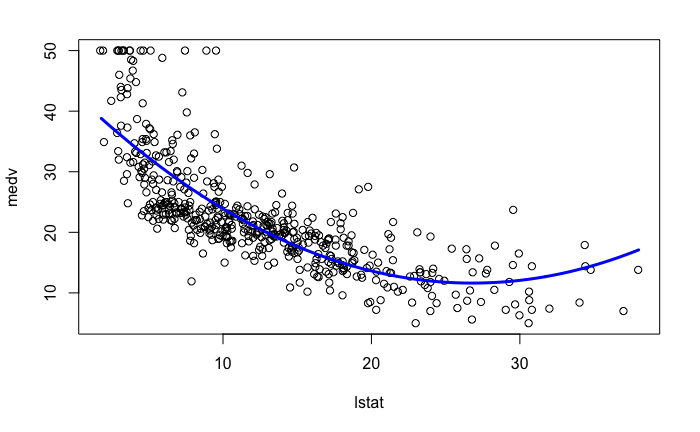

```r
plot(lstat ,medv)
lines(lstat_values, predictedcounts, col = "blue", lwd = 3)
```

# MULTIPLES LINEAR REGRESSION

```r
lm.fit=lm(medv~lstat+age,data=Boston)
summary(lm.fit)
```

```
Call:
lm(formula = medv ~ lstat + age, data = Boston)

Residuals:
    Min      1Q  Median      3Q     Max
-15.981  -3.978  -1.283   1.968  23.158

Coefficients:
            Estimate Std. Error t value Pr(>|t|)
(Intercept) 33.22276    0.73085  45.458  < 2e-16 ***
lstat       -1.03207    0.04819 -21.416  < 2e-16 ***
age          0.03454    0.01223   2.826  0.00491 **
---
Signif. codes:  0 ‘***’ 0.001 ‘**’ 0.01 ‘*’ 0.05 ‘.’ 0.1 ‘ ’ 1

Residual standard error: 6.173 on 503 degrees of freedom
Multiple R-squared:  0.5513,    Adjusted R-squared:  0.5495
F-statistic:   309 on 2 and 503 DF,  p-value: < 2.2e-16
```

Podemos hacerlo con todas las variables

```r
lm.fit=lm(medv~.,data=Boston)
summary(lm.fit)
```

```
Call:
lm(formula = medv ~ ., data = Boston)

Residuals:
    Min      1Q  Median      3Q     Max
-15.595  -2.730  -0.518   1.777  26.199

Coefficients:
              Estimate Std. Error t value Pr(>|t|)
(Intercept)  3.646e+01  5.103e+00   7.144 3.28e-12 ***
crim        -1.080e-01  3.286e-02  -3.287 0.001087 **
zn           4.642e-02  1.373e-02   3.382 0.000778 ***
indus        2.056e-02  6.150e-02   0.334 0.738288
chas         2.687e+00  8.616e-01   3.118 0.001925 **
nox         -1.777e+01  3.820e+00  -4.651 4.25e-06 ***
rm           3.810e+00  4.179e-01   9.116  < 2e-16 ***
age          6.922e-04  1.321e-02   0.052 0.958229
dis         -1.476e+00  1.995e-01  -7.398 6.01e-13 ***
rad          3.060e-01  6.635e-02   4.613 5.07e-06 ***
tax         -1.233e-02  3.760e-03  -3.280 0.001112 **
ptratio     -9.527e-01  1.308e-01  -7.283 1.31e-12 ***
black        9.312e-03  2.686e-03   3.467 0.000573 ***
lstat       -5.248e-01  5.072e-02 -10.347  < 2e-16 ***
---
Signif. codes:  0 ‘***’ 0.001 ‘**’ 0.01 ‘*’ 0.05 ‘.’ 0.1 ‘ ’ 1

Residual standard error: 4.745 on 492 degrees of freedom
Multiple R-squared:  0.7406,    Adjusted R-squared:  0.7338
F-statistic: 108.1 on 13 and 492 DF,  p-value: < 2.2e-16
```

```r
names(lm.fit)
```

```
 [1] "coefficients"  "residuals"     "effects"       "rank"          "fitted.values" "assign"        "qr"            "df.residual"
 [9] "xlevels"       "call"          "terms"         "model"
```

Transformaciones no lineales we can create a predictor X2

```r
lm.fit2=lm(medv~lstat+I(lstat^2))
summary(lm.fit2)
```

```
Call:
lm(formula = medv ~ lstat + I(lstat^2))

Residuals:
     Min       1Q   Median       3Q      Max
-15.2834  -3.8313  -0.5295   2.3095  25.4148

Coefficients:
             Estimate Std. Error t value Pr(>|t|)
(Intercept) 42.862007   0.872084   49.15   <2e-16 ***
lstat       -2.332821   0.123803  -18.84   <2e-16 ***
I(lstat^2)   0.043547   0.003745   11.63   <2e-16 ***
---
Signif. codes:  0 ‘***’ 0.001 ‘**’ 0.01 ‘*’ 0.05 ‘.’ 0.1 ‘ ’ 1

Residual standard error: 5.524 on 503 degrees of freedom
Multiple R-squared:  0.6407,    Adjusted R-squared:  0.6393
F-statistic: 448.5 on 2 and 503 DF,  p-value: < 2.2e-16
```

Vamos a usar una Anova para ver cual se ajusta mejor, el lineal o el X^2

```r
lm.fit=lm(medv~lstat)
anova(lm.fit ,lm.fit2)
```

```
Analysis of Variance Table

Model 1: medv ~ lstat
Model 2: medv ~ lstat + I(lstat^2)
  Res.Df   RSS Df Sum of Sq     F    Pr(>F)
1    504 19472
2    503 15347  1    4125.1 135.2 < 2.2e-16 ***
---
Signif. codes:  0 ‘***’ 0.001 ‘**’ 0.01 ‘*’ 0.05 ‘.’ 0.1 ‘ ’ 1
```

The anova() function performs a hypothesis test comparing the two models. The null hypothesis is that the two models fit the data equally well, and the alternative hypothesis is that the full model is superior. Here the F-statistic is 135 and the associated p-value is virtually zero. This provides very clear evidence that the model containing the predictors lstat and lstat2 is far superior to the model that only contains the predictor lstat. This is not surprising, since earlier we saw evidence for non-linearity in the relationship between medv and lstat.

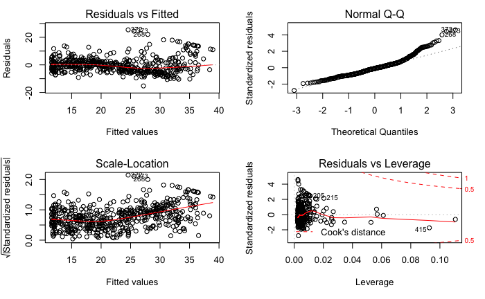

```r
par(mfrow=c(2,2))
plot(lm.fit2)
```

then we see that when the lstat2 term is included in the model, there is little discernible pattern in the residuals.

Vamos a crear una aproximación cúbiva: In order to create a cubic fit, we can include a predictor of the form I(X^3). However, this approach can start to get cumbersome for higher- order polynomials. A better approach involves using the poly() function to create the polynomial within lm(). For example, the following command produces a fifth-order polynomial fit:

```r
lm.fit5=lm(medv~poly(lstat ,5))
summary(lm.fit5)
```

```
Call:
lm(formula = medv ~ poly(lstat, 5))

Residuals:
     Min       1Q   Median       3Q      Max
-13.5433  -3.1039  -0.7052   2.0844  27.1153

Coefficients:
                 Estimate Std. Error t value Pr(>|t|)
(Intercept)       22.5328     0.2318  97.197  < 2e-16 ***
poly(lstat, 5)1 -152.4595     5.2148 -29.236  < 2e-16 ***
poly(lstat, 5)2   64.2272     5.2148  12.316  < 2e-16 ***
poly(lstat, 5)3  -27.0511     5.2148  -5.187 3.10e-07 ***
poly(lstat, 5)4   25.4517     5.2148   4.881 1.42e-06 ***
poly(lstat, 5)5  -19.2524     5.2148  -3.692 0.000247 ***
---
Signif. codes:  0 ‘***’ 0.001 ‘**’ 0.01 ‘*’ 0.05 ‘.’ 0.1 ‘ ’ 1

Residual standard error: 5.215 on 500 degrees of freedom
Multiple R-squared:  0.6817,    Adjusted R-squared:  0.6785
F-statistic: 214.2 on 5 and 500 DF,  p-value: < 2.2e-16
```

This suggests that including additional polynomial terms, up to fifth order, leads to an improvement in the model fit! However, further investigation of the data reveals that no polynomial terms beyond fifth order have signifi- cant p-values in a regression fit.

```r
data(Carseats)
head(Carseats)
```

|  | Sales | CompPrice | Income | Advertising | Population | Price | ShelveLoc | Age | Education | Urban | US |
| --- | --- | --- | --- | --- | --- | --- | --- | --- | --- | --- | --- |
| 1 | 9.50 | 138 | 73 | 11 | 276 | 120 | Bad | 42 | 17 | Yes | Yes |
| 2 | 11.22 | 111 | 48 | 16 | 260 | 83 | Good | 65 | 10 | Yes | Yes |
| 3 | 10.06 | 113 | 35 | 10 | 269 | 80 | Medium | 59 | 12 | Yes | Yes |
| 4 | 7.40 | 117 | 100 | 4 | 466 | 97 | Medium | 55 | 14 | Yes | Yes |
| 5 | 4.15 | 141 | 64 | 3 | 340 | 128 | Bad | 38 | 13 | Yes | No |
| 6 | 10.81 | 124 | 113 | 13 | 501 | 72 | Bad | 78 | 16 | No | Yes |

```r
attach(Carseats)
```

The Carseats data includes qualitative predictors such as Shelveloc, an in- dicator of the quality of the shelving location—that is, the space within a store in which the car seat is displayed—at each location. The pre- dictor Shelveloc takes on three possible values, Bad, Medium, and Good.

Given a qualitative variable such as Shelveloc, R generates dummy variables automatically. Below we fit a multiple regression model that includes some interaction terms.

```r
lm.fit=lm(Sales~.+Income:Advertising+Price:Age,data=Carseats)
summary(lm.fit)
```

```
Call:
lm(formula = Sales ~ . + Income:Advertising + Price:Age, data = Carseats)

Residuals:
    Min      1Q  Median      3Q     Max
-2.9208 -0.7503  0.0177  0.6754  3.3413

Coefficients:
                     Estimate Std. Error t value Pr(>|t|)
(Intercept)         6.5755654  1.0087470   6.519 2.22e-10 ***
CompPrice           0.0929371  0.0041183  22.567  < 2e-16 ***
Income              0.0108940  0.0026044   4.183 3.57e-05 ***
Advertising         0.0702462  0.0226091   3.107 0.002030 **
Population          0.0001592  0.0003679   0.433 0.665330
Price              -0.1008064  0.0074399 -13.549  < 2e-16 ***
ShelveLocGood       4.8486762  0.1528378  31.724  < 2e-16 ***
ShelveLocMedium     1.9532620  0.1257682  15.531  < 2e-16 ***
Age                -0.0579466  0.0159506  -3.633 0.000318 ***
Education          -0.0208525  0.0196131  -1.063 0.288361
UrbanYes            0.1401597  0.1124019   1.247 0.213171
USYes              -0.1575571  0.1489234  -1.058 0.290729
Income:Advertising  0.0007510  0.0002784   2.698 0.007290 **
Price:Age           0.0001068  0.0001333   0.801 0.423812
---
Signif. codes:  0 ‘***’ 0.001 ‘**’ 0.01 ‘*’ 0.05 ‘.’ 0.1 ‘ ’ 1

Residual standard error: 1.011 on 386 degrees of freedom
Multiple R-squared:  0.8761,    Adjusted R-squared:  0.8719
F-statistic:   210 on 13 and 386 DF,  p-value: < 2.2e-16
```

```r
contrasts(ShelveLoc)
```

```
       Good Medium
Bad       0      0
Good      1      0
Medium    0      1
```